# Project3

## Background

AllLife Bank is a US bank that has a growing customer base. The majority of these customers are liability customers (depositors) with varying sizes of deposits. The number of customers who are also borrowers (asset customers) is quite small, and the bank is interested in expanding this base rapidly to bring in more loan business and in the process, earn more through the interest on loans. In particular, the management wants to explore ways of converting its liability customers to personal loan customers (while retaining them as depositors).

### Context

A campaign that the bank ran last year for liability customers showed a healthy conversion rate of over 9% success. This has encouraged the retail marketing department to devise campaigns with better target marketing to increase the success ratio.

### Task

You as a Data scientist at AllLife bank have to build a model that will help the marketing department to identify the potential customers who have a higher probability of purchasing the loan.

### Objective

To predict whether a liability customer will buy a personal loan or not. Which variables are most significant. Which segment of customers should be targeted more.

### Data Dictionary

- ID: Customer ID
- Age: Customer’s age in completed years
- Experience: #years of professional experience
- Income: Annual income of the customer (in thousand dollars)
- ZIP Code: Home Address ZIP code.
- Family: the Family size of the customer
- CCAvg: Average spending on credit cards per month (in thousand dollars)
- Education: Education Level. 1: Undergrad; 2: Graduate;3: Advanced/Professional
- Mortgage: Value of house mortgage if any. (in thousand dollars)
- Personal_Loan: Did this customer accept the personal loan offered in the last campaign?
- Securities_Account: Does the customer have securities account with the bank?
- CD_Account: Does the customer have a certificate of deposit (CD) account with the bank?
- Online: Do customers use internet banking facilities?
- CreditCard: Does the customer use a credit card issued by any other Bank (excluding All life Bank)?

### Sub-Tasks

Perform an Exploratory Data Analysis on the data

- Univariate analysis
- Bivariate analysis
- Use appropriate visualizations to identify the patterns and insights
- Any other exploratory deep dive

Illustrate the insights based on EDA

- Key meaningful observations on the relationship between variables

Data Pre-processing

- Prepare the data for analysis - Missing value Treatment, Outlier Detection(treat, if needed), Feature Engineering, - Prepare data for modelling and check the split

Model building - Logistic Regression

- Build the model and comment on the model statistics
- Test assumptions
- Filter out key variables that have a strong relationship with the dependent variable

Model performance evaluation and improvement

- Comment on which metric is right for model performance evaluation and why?
- Comment on model performance
- Can model performance be improved? if yes then do it

Model building - Decision Tree

- Build the model and comment on the model statistics
- Identify the key variables that have a strong relationship with the dependent variable

Model performance evaluation and improvement

- Evaluate the model on appropriate metric
- Comment on model performance
- Can model performance be improved? if yes then do it

Actionable Insights & Recommendations

- Compare decision tree and Logistic regression
- Conclude with the key takeaways for the marketing team
- what would your advice be on how to do this campaign?

Misclassification analysis

- Do an analysis of all misclassified samples
- Try to find a pattern among those

Notebook - Overall

- Conclude with the key takeaways for the business
- What would your advice be to grow the business?

```python
#essentials
import pandas as pd
import seaborn as sns
import matplotlib.pyplot as plt
import numpy as np

#removes imit from the number of displayed columns and rows
pd.set_option("display.max_columns", None)
pd.set_option("display.max_rows", 200)

#stats models
import scipy.stats as stats
import statsmodels.stats.api as sms
from statsmodels.stats.outliers_influence import variance_inflation_factor
from statsmodels.tools.tools import add_constant

#decision tree packages
from sklearn import tree
from sklearn.tree import DecisionTreeClassifier
from sklearn import metrics
from sklearn.metrics import accuracy_score, recall_score, precision_score, roc_auc_score, roc_curve, confusion_matrix, precision_recall_curve, f1_score
from sklearn.model_selection import GridSearchCV

#classification packages
from sklearn.linear_model import LogisticRegression
from sklearn.model_selection import train_test_split
from sklearn.metrics import accuracy_score,precision_score,recall_score,f1_score, classification_report
```

```python
data = pd.read_csv('Loan_Modelling.csv') #read the csv.file
loan = data.copy()
```

# Initial Dataset Exploration

```python
np.random.seed(1) #sets the same random samples each time
loan.sample(10) #random sample of 10
```

|  | ID | Age | Experience | Income | ZIPCode | Family | CCAvg | Education | Mortgage | Personal_Loan | Securities_Account | CD_Account | Online | CreditCard |
| --- | --- | --- | --- | --- | --- | --- | --- | --- | --- | --- | --- | --- | --- | --- |
| 2764 | 2765 | 31 | 5 | 84 | 91320 | 1 | 2.9 | 3 | 105 | 0 | 0 | 0 | 0 | 1 |
| 4767 | 4768 | 35 | 9 | 45 | 90639 | 3 | 0.9 | 1 | 101 | 0 | 1 | 0 | 0 | 0 |
| 3814 | 3815 | 34 | 9 | 35 | 94304 | 3 | 1.3 | 1 | 0 | 0 | 0 | 0 | 0 | 0 |
| 3499 | 3500 | 49 | 23 | 114 | 94550 | 1 | 0.3 | 1 | 286 | 0 | 0 | 0 | 1 | 0 |
| 2735 | 2736 | 36 | 12 | 70 | 92131 | 3 | 2.6 | 2 | 165 | 0 | 0 | 0 | 1 | 0 |
| 3922 | 3923 | 31 | 4 | 20 | 95616 | 4 | 1.5 | 2 | 0 | 0 | 0 | 0 | 1 | 0 |
| 2701 | 2702 | 50 | 26 | 55 | 94305 | 1 | 1.6 | 2 | 0 | 0 | 0 | 0 | 1 | 0 |
| 1179 | 1180 | 36 | 11 | 98 | 90291 | 3 | 1.2 | 3 | 0 | 0 | 1 | 0 | 0 | 1 |
| 932 | 933 | 51 | 27 | 112 | 94720 | 3 | 1.8 | 2 | 0 | 0 | 1 | 1 | 1 | 1 |
| 792 | 793 | 41 | 16 | 98 | 93117 | 1 | 4.0 | 3 | 0 | 0 | 0 | 0 | 0 | 1 |

```python
loan.shape #(r,c)
print(f'There are {loan.shape[0]} rows and {loan.shape[1]} columns.') #r and c printed in full sentence
```

```
There are 5000 rows and 14 columns.
```

```python
loan.info() #check datatypes
```

```
<class 'pandas.core.frame.DataFrame'>
RangeIndex: 5000 entries, 0 to 4999
Data columns (total 14 columns):
 #   Column              Non-Null Count  Dtype
---  ------              --------------  -----
 0   ID                  5000 non-null   int64
 1   Age                 5000 non-null   int64
 2   Experience          5000 non-null   int64
 3   Income              5000 non-null   int64
 4   ZIPCode             5000 non-null   int64
 5   Family              5000 non-null   int64
 6   CCAvg               5000 non-null   float64
 7   Education           5000 non-null   int64
 8   Mortgage            5000 non-null   int64
 9   Personal_Loan       5000 non-null   int64
 10  Securities_Account  5000 non-null   int64
 11  CD_Account          5000 non-null   int64
 12  Online              5000 non-null   int64
 13  CreditCard          5000 non-null   int64
dtypes: float64(1), int64(13)
memory usage: 547.0 KB
```

```python
loan[loan.duplicated()].count() #identify duplicates
```

```
ID                    0
Age                   0
Experience            0
Income                0
ZIPCode               0
Family                0
CCAvg                 0
Education             0
Mortgage              0
Personal_Loan         0
Securities_Account    0
CD_Account            0
Online                0
CreditCard            0
dtype: int64
```

```python
loan.isnull().sum() #identify null values
```

```
ID                    0
Age                   0
Experience            0
Income                0
ZIPCode               0
Family                0
CCAvg                 0
Education             0
Mortgage              0
Personal_Loan         0
Securities_Account    0
CD_Account            0
Online                0
CreditCard            0
dtype: int64
```

```python
pd.DataFrame(data={"% of Missing Values": round(loan.isna().sum() / loan.isna().count() * 100, 2)}) #% of missing values
```

[output not shown]

no missing values, and all values are either integers or floats. some integers can be changed into categories

```python
#change integers into categorical values

loan["Family"] = loan["Family"].astype("category")
loan["Personal_Loan"] = loan["Personal_Loan"].astype("category")
loan["Securities_Account"] = loan["Securities_Account"].astype("category")
loan["CD_Account"] = loan["CD_Account"].astype("category")
loan["Online"] = loan["Online"].astype("category")
loan["CreditCard"] = loan["CreditCard"].astype("category")
loan["Education"] = loan["Education"].astype("category")
```

```python
loan.info()
```

```
<class 'pandas.core.frame.DataFrame'>
RangeIndex: 5000 entries, 0 to 4999
Data columns (total 14 columns):
 #   Column              Non-Null Count  Dtype
---  ------              --------------  -----
 0   ID                  5000 non-null   int64
 1   Age                 5000 non-null   int64
 2   Experience          5000 non-null   int64
 3   Income              5000 non-null   int64
 4   ZIPCode             5000 non-null   int64
 5   Family              5000 non-null   category
 6   CCAvg               5000 non-null   float64
 7   Education           5000 non-null   category
 8   Mortgage            5000 non-null   int64
 9   Personal_Loan       5000 non-null   category
 10  Securities_Account  5000 non-null   category
 11  CD_Account          5000 non-null   category
 12  Online              5000 non-null   category
 13  CreditCard          5000 non-null   category
dtypes: category(7), float64(1), int64(6)
memory usage: 308.5 KB
```

```python
loan.drop(["ID"],axis=1,inplace=True)
```

```python
loan.drop(["ZIPCode"],axis=1,inplace=True)
```

dropped both ID and ZIPCode which are irrelevant to the analysis

```python
loan.describe(include='all').T
```

[output not shown]

```python
loan["Experience"].unique() #check the different values of columns for abnormality, the rest are fine so not included
```

```
array([ 1, 19, 15,  9,  8, 13, 27, 24, 10, 39,  5, 23, 32, 41, 30, 14, 18,
       21, 28, 31, 11, 16, 20, 35,  6, 25,  7, 12, 26, 37, 17,  2, 36, 29,
        3, 22, -1, 34,  0, 38, 40, 33,  4, -2, 42, -3, 43])
```

all columns seem to have reasonable values, except negative values under experience, which could be just noise

```python
loan["Family"].value_counts()
```

```
1    1472
2    1296
4    1222
3    1010
Name: Family, dtype: int64
```

```python
loan["Education"].value_counts()
```

```
1    2096
3    1501
2    1403
Name: Education, dtype: int64
```

```python
loan['Mortgage'].value_counts()
```

```
0      3462
98       17
103      16
119      16
83       16
       ...
541       1
509       1
505       1
485       1
577       1
Name: Mortgage, Length: 347, dtype: int64
```

```python
loan['Personal_Loan'].value_counts()
```

```
0    4520
1     480
Name: Personal_Loan, dtype: int64
```

```python
loan['Securities_Account'].value_counts()
```

```
0    4478
1     522
Name: Securities_Account, dtype: int64
```

```python
loan['CD_Account'].value_counts()
```

```
0    4698
1     302
Name: CD_Account, dtype: int64
```

```python
loan['Online'].value_counts()
```

```
1    2984
0    2016
Name: Online, dtype: int64
```

```python
loan['CreditCard'].value_counts()
```

```
0    3530
1    1470
Name: CreditCard, dtype: int64
```

# EDA

### univariate

```python
# Function to create barplots that indicate percentage for each category

def perc_on_bar(plot, feature):
    '''
    plot
    feature: categorical feature
    the function won't work if a column is passed in hue parameter
    '''
    total = len(feature) # length of the column
    for p in ax.patches:
        percentage = '{:.1f}%'.format(100 * p.get_height()/total) # percentage of each class of the category
        x = p.get_x() + p.get_width() / 2 - 0.05 # width of the plot
        y = p.get_y() + p.get_height()           # hieght of the plot
        ax.annotate(percentage, (x, y), size = 12) # annotate the percantage
    plt.show() # show the plot
```

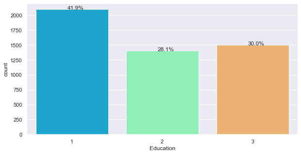

```python
# % breakdown of the categories in education

plt.figure(figsize=(10,5))
ax = sns.countplot(loan["Education"],palette='rainbow')
perc_on_bar(ax,loan["Education"])
```

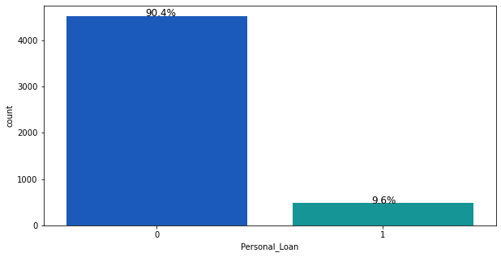

```python
# proportion of clients who have received a personal loan in the last campagin

plt.figure(figsize=(10,5))
ax = sns.countplot(loan["Personal_Loan"],palette='winter')
perc_on_bar(ax,loan["Personal_Loan"])
```

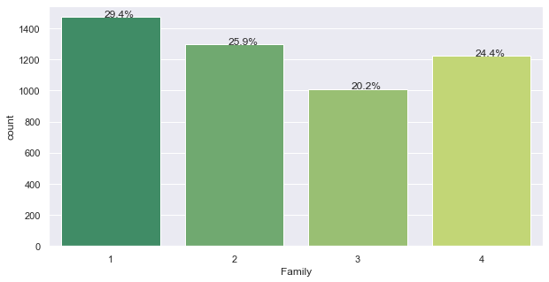

```python
# % breakdown of the sizes of family

plt.figure(figsize=(10,5))
ax = sns.countplot(loan["Family"],palette='summer')
perc_on_bar(ax,loan["Family"])
```

```python
# Function to plot stacked bar chart

def stacked_plot(x):
    sns.set(palette='nipy_spectral')
    tab1 = pd.crosstab(x,loan['Personal_Loan'],margins=True)
    print(tab1)
    print('-'*120)
    tab = pd.crosstab(x,loan['Personal_Loan'],normalize='index')
    tab.plot(kind='bar',stacked=True,figsize=(10,5))
    #plt.legend(loc='lower left', frameon=False)
    #plt.legend(loc="upper left", bbox_to_anchor=(0,1))
    plt.show()
```

```
Personal_Loan     0    1   All
Family
1              1365  107  1472
2              1190  106  1296
3               877  133  1010
4              1088  134  1222
All            4520  480  5000
------------------------------------------------------------------------------------------------------------------------
```

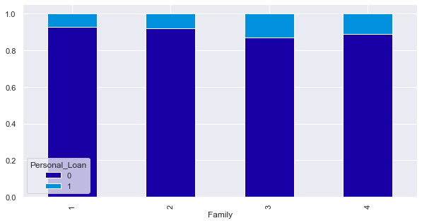

```python
stacked_plot(loan['Family'])
```

```
Personal_Loan     0    1   All
Education
1              2003   93  2096
2              1221  182  1403
3              1296  205  1501
All            4520  480  5000
------------------------------------------------------------------------------------------------------------------------
```

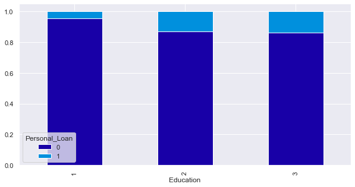

```python
stacked_plot(loan['Education'])
```

```python
def stacked_plot_Education(x):
    sns.set(palette='nipy_spectral')
    tab1 = pd.crosstab(x,loan['Education'],margins=True)
    print(tab1)
    print('-'*120)
    tab = pd.crosstab(x,loan['Education'],normalize='index')
    tab.plot(kind='bar',stacked=True,figsize=(10,5))
    #plt.legend(loc='lower left', frameon=False)
    #plt.legend(loc="upper left", bbox_to_anchor=(0,1))
    plt.show()
```

```
Education     1     2     3   All
Family
1           678   326   468  1472
2           657   265   374  1296
3           349   383   278  1010
4           412   429   381  1222
All        2096  1403  1501  5000
------------------------------------------------------------------------------------------------------------------------
```

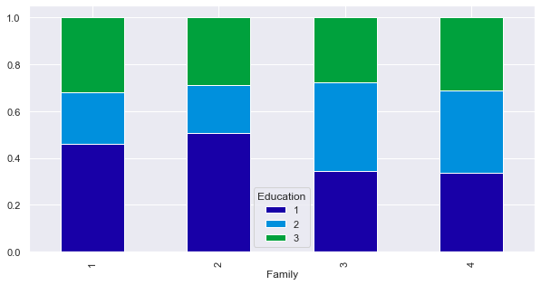

```python
stacked_plot_Education(loan['Family'])
```

```
Education         1     2     3   All
Personal_Loan
0              2003  1221  1296  4520
1                93   182   205   480
All            2096  1403  1501  5000
------------------------------------------------------------------------------------------------------------------------
```

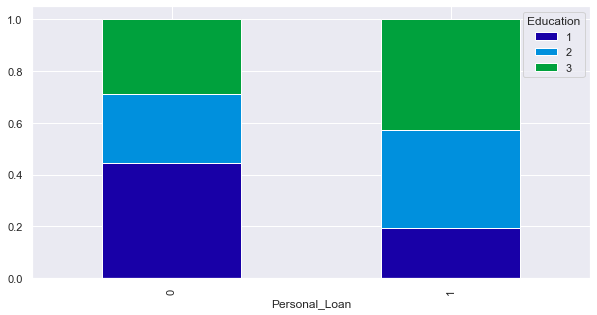

```python
stacked_plot_Education(loan['Personal_Loan'])
```

### Chi square tests on education, family and income to show statistical significance

```python
crosstab = pd.crosstab(loan['Education'],loan['Personal_Loan'])  # Contingency table of region and smoker attributes

Ho = "Education has no effect on Personal Loan"   # Stating the Null Hypothesis
Ha = "Education has an effect on Personal Loan"   # Stating the Alternate Hypothesis

chi, p_value, dof, expected =  stats.chi2_contingency(crosstab)

if p_value < 0.05:  # Setting our significance level at 5%
    print(f'{Ha} as the p_value ({p_value.round(3)}) < 0.05')
else:
    print(f'{Ho} as the p_value ({p_value.round(3)}) > 0.05')
```

```
Education has an effect on Personal Loan as the p_value (0.0) < 0.05
```

```python
crosstab = pd.crosstab(loan['Family'],loan['Personal_Loan'])  # Contingency table of region and smoker attributes

Ho = "Family has no effect on Personal Loan"   # Stating the Null Hypothesis
Ha = "Family has an effect on Personal Loan"   # Stating the Alternate Hypothesis

chi, p_value, dof, expected =  stats.chi2_contingency(crosstab)

if p_value < 0.05:  # Setting our significance level at 5%
    print(f'{Ha} as the p_value ({p_value.round(3)}) < 0.05')
else:
    print(f'{Ho} as the p_value ({p_value.round(3)}) > 0.05')
```

```
Family has an effect on Personal Loan as the p_value (0.0) < 0.05
```

```python
crosstab = pd.crosstab(loan['Income'],loan['Personal_Loan'])  # Contingency table of region and smoker attributes

Ho = "Income has no effect on Personal Loan"   # Stating the Null Hypothesis
Ha = "Income has an effect on Personal Loan"   # Stating the Alternate Hypothesis

chi, p_value, dof, expected =  stats.chi2_contingency(crosstab)

if p_value < 0.05:  # Setting our significance level at 5%
    print(f'{Ha} as the p_value ({p_value.round(3)}) < 0.05')
else:
    print(f'{Ho} as the p_value ({p_value.round(3)}) > 0.05')
```

```
Income has an effect on Personal Loan as the p_value (0.0) < 0.05
```

P-value for all tests < 0.01. Hence, all the differences that we see in the 2 plots are statistically significant.

```python
# a function that takes the numerical column as the input and returns the boxplots and histograms for the variable

def histogram_boxplot(feature, figsize=(15,10), bins = None):
    f2, (ax_box2, ax_hist2) = plt.subplots(nrows = 2, # Number of rows of the subplot grid= 2
                                           sharex = True, # x-axis will be shared among all subplots
                                           gridspec_kw = {"height_ratios": (.25, .75)},
                                           figsize = figsize
                                           ) # creating the 2 subplots
    sns.boxplot(feature, ax=ax_box2, showmeans=True, color='violet') # boxplot will be created and a star will indicate the mean value of the column
    sns.distplot(feature, kde=F, ax=ax_hist2, bins=bins,palette="winter") if bins else sns.distplot(feature, kde=False, ax=ax_hist2) # For histogram
    ax_hist2.axvline(np.mean(feature), color='green', linestyle='--') # Add mean to the histogram
    ax_hist2.axvline(np.median(feature), color='black', linestyle='-') # Add median to the histogram
```

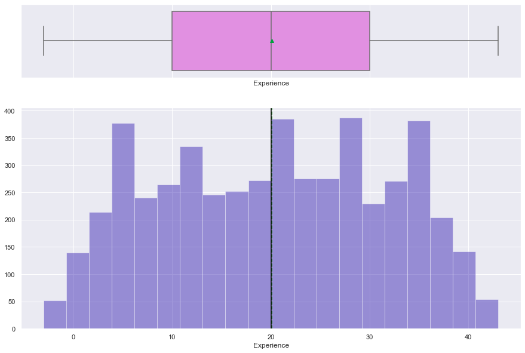

```python
histogram_boxplot(loan["Experience"])
```

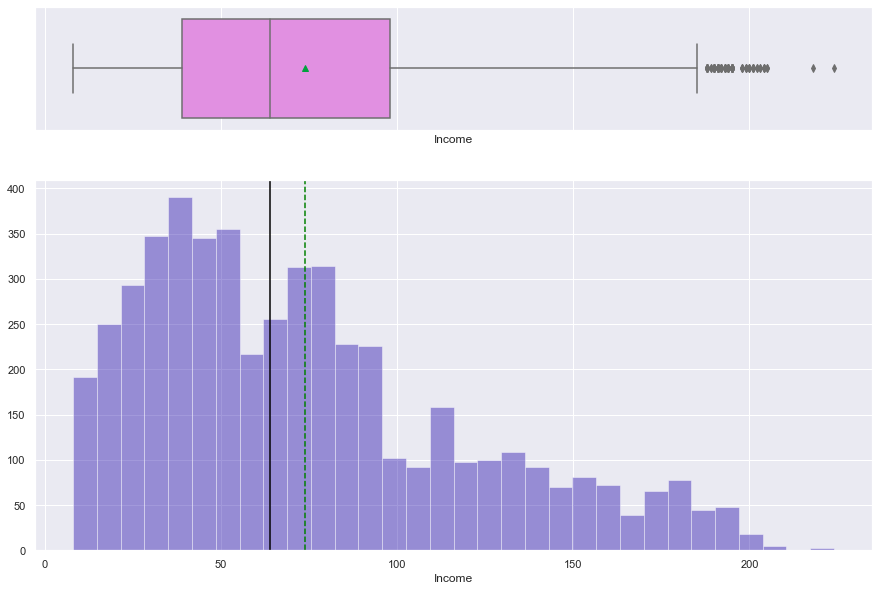

```python
histogram_boxplot(loan["Income"])
```

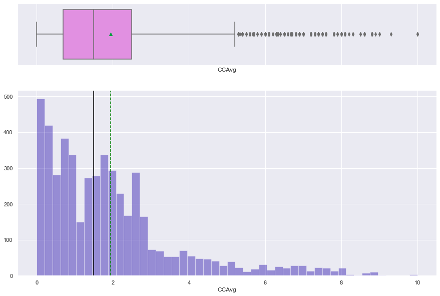

```python
histogram_boxplot(loan["CCAvg"])
```

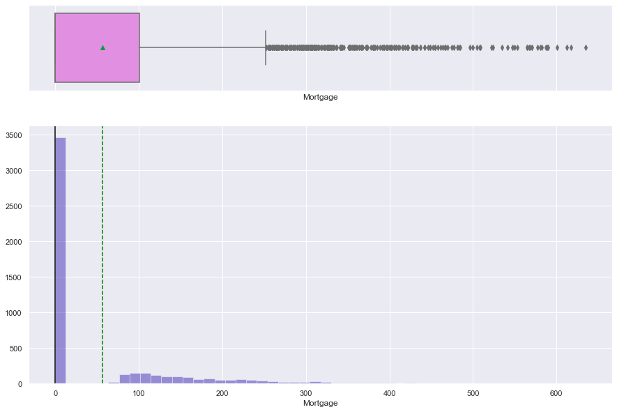

```python
histogram_boxplot(loan["Mortgage"])
```

### bivariate

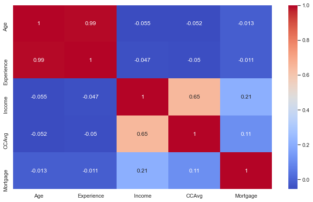

```python
# heatmap to show correlations between the variables

plt.figure(figsize=(12, 7))
sns.heatmap(loan.corr(), annot=True, cmap="coolwarm")
plt.show()
```

# Model Building: Decision Tree

1. Data preparation.
2. Partition the data into train and test set.
3. Built a CART model on the train data.
4. Tune the model and prune the tree.
5. Test the data on test set.

```python
#split data

x = loan.drop(["Personal_Loan"], axis=1)
y = loan["Personal_Loan"]
```

```python
# encoding the categorical variables

x = pd.get_dummies(x, drop_first=True)
x.head()
```

|  | Age | Experience | Income | CCAvg | Mortgage | Family_2 | Family_3 | Family_4 | Education_2 | Education_3 | Securities_Account_1 | CD_Account_1 | Online_1 | CreditCard_1 |
| --- | --- | --- | --- | --- | --- | --- | --- | --- | --- | --- | --- | --- | --- | --- |
| 0 | 25 | 1 | 49 | 1.6 | 0 | 0 | 0 | 1 | 0 | 0 | 1 | 0 | 0 | 0 |
| 1 | 45 | 19 | 34 | 1.5 | 0 | 0 | 1 | 0 | 0 | 0 | 1 | 0 | 0 | 0 |
| 2 | 39 | 15 | 11 | 1.0 | 0 | 0 | 0 | 0 | 0 | 0 | 0 | 0 | 0 | 0 |
| 3 | 35 | 9 | 100 | 2.7 | 0 | 0 | 0 | 0 | 1 | 0 | 0 | 0 | 0 | 0 |
| 4 | 35 | 8 | 45 | 1.0 | 0 | 0 | 0 | 1 | 1 | 0 | 0 | 0 | 0 | 1 |

```python
xtrain, xtest, ytrain, ytest = train_test_split(x, y, test_size=0.4 , random_state=1)
```

```python
print(xtrain.shape)
print(xtest.shape)
print(ytrain.shape)
print(ytest.shape)
```

```
(3000, 14)
(2000, 14)
(3000,)
(2000,)
```

```python
y.value_counts()
```

```
0    4520
1     480
Name: Personal_Loan, dtype: int64
```

```python
model = DecisionTreeClassifier(criterion = 'gini', random_state=1)
model.fit(xtrain, ytrain)
```

```
DecisionTreeClassifier(random_state=1)
```

```python
# accuracy on training set
print("Accuracy on train set", model.score(xtrain,ytrain))

# accuracy on test set
print("Accuracy on test set", model.score(xtest,ytest))
```

```
Accuracy on train set 1.0
Accuracy on test set 0.981
```

What does the bank want?

The bank wants to increase the number of clients who would go for the personal loan.

```python
# Function to create confusion matrix

def make_confusion_matrix(model,y_actual,labels=[1, 0]):
    '''
    model : classifier to predict values of X
    y_actual : ground truth

    '''
    y_predict = model.predict(xtest)
    cm=metrics.confusion_matrix( y_actual, y_predict, labels=[0, 1])
    df_cm = pd.DataFrame(cm, index = [i for i in ["Actual - No","Actual - Yes"]],
                  columns = [i for i in ['Predicted - No','Predicted - Yes']])
    group_counts = ["{0:0.0f}".format(value) for value in
                cm.flatten()]
    group_percentages = ["{0:.2%}".format(value) for value in
                         cm.flatten()/np.sum(cm)]
    labels = [f"{v1}\n{v2}" for v1, v2 in
              zip(group_counts,group_percentages)]
    labels = np.asarray(labels).reshape(2,2)
    plt.figure(figsize = (10,7))
    sns.heatmap(df_cm, annot=labels,fmt='')
    plt.ylabel('True label')
    plt.xlabel('Predicted label')
```

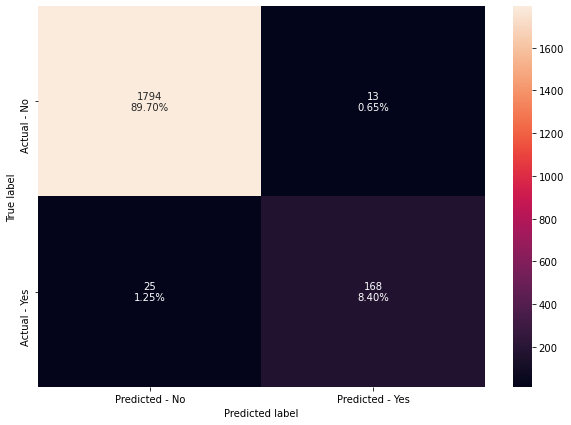

```python
make_confusion_matrix(model,ytest)
```

```python
# Function to calculate recall score

def get_recall_score(model): # classifier to predict values of X

    pred_train = model.predict(xtrain)
    pred_test = model.predict(xtest)
    print("Recall on training set : ",metrics.recall_score(ytrain,pred_train))
    print("Recall on test set : ",metrics.recall_score(ytest,pred_test))
```

```python
get_recall_score(model)
```

```
Recall on training set :  1.0
Recall on test set :  0.8704663212435233
```

Recall on both sets are good

```python
column_names = list(x.columns)
feature_names = column_names
print(feature_names)
```

```
['Age', 'Experience', 'Income', 'CCAvg', 'Mortgage', 'Family_2', 'Family_3', 'Family_4', 'Education_2', 'Education_3', 'Securities_Account_1', 'CD_Account_1', 'Online_1', 'CreditCard_1']
```

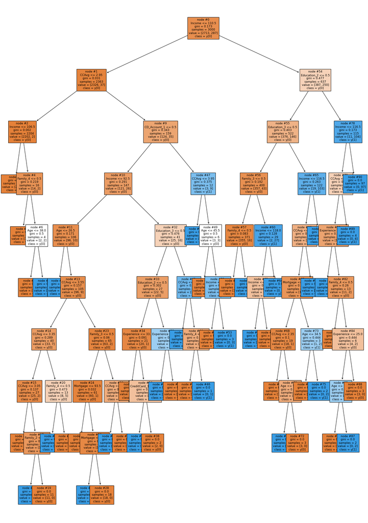

```python
# decision tree

plt.figure(figsize=(20,30))

out = tree.plot_tree(model,feature_names=feature_names,filled=True,fontsize=9,node_ids=True,class_names=True)
for o in out:
     arrow = o.arrow_patch
     if arrow is not None:
        arrow.set_edgecolor('black')
        arrow.set_linewidth(1)
plt.show()
```

```python
# Text report showing the rules of a decision tree

print(tree.export_text(model,feature_names=feature_names,show_weights=True))
```

```
|--- Income <= 110.50
|   |--- CCAvg <= 2.95
|   |   |--- Income <= 106.50
|   |   |   |--- weights: [2188.00, 0.00] class: 0
|   |   |--- Income >  106.50
|   |   |   |--- Family_4 <= 0.50
|   |   |   |   |--- weights: [12.00, 0.00] class: 0
|   |   |   |--- Family_4 >  0.50
|   |   |   |   |--- Age <= 38.00
|   |   |   |   |   |--- weights: [2.00, 0.00] class: 0
|   |   |   |   |--- Age >  38.00
|   |   |   |   |   |--- weights: [0.00, 2.00] class: 1
|   |--- CCAvg >  2.95
|   |   |--- CD_Account_1 <= 0.50
|   |   |   |--- Income <= 92.50
|   |   |   |   |--- Age <= 26.50
|   |   |   |   |   |--- weights: [0.00, 1.00] class: 1
|   |   |   |   |--- Age >  26.50
|   |   |   |   |   |--- CCAvg <= 3.55
|   |   |   |   |   |   |--- CCAvg <= 3.35
|   |   |   |   |   |   |   |--- CCAvg <= 3.05
|   |   |   |   |   |   |   |   |--- weights: [14.00, 0.00] class: 0
|   |   |   |   |   |   |   |--- CCAvg >  3.05
|   |   |   |   |   |   |   |   |--- Family_2 <= 0.50
|   |   |   |   |   |   |   |   |   |--- weights: [0.00, 2.00] class: 1
|   |   |   |   |   |   |   |   |--- Family_2 >  0.50
|   |   |   |   |   |   |   |   |   |--- weights: [11.00, 0.00] class: 0
|   |   |   |   |   |   |--- CCAvg >  3.35
|   |   |   |   |   |   |   |--- Family_4 <= 0.50
|   |   |   |   |   |   |   |   |--- weights: [0.00, 5.00] class: 1
|   |   |   |   |   |   |   |--- Family_4 >  0.50
|   |   |   |   |   |   |   |   |--- weights: [8.00, 0.00] class: 0
|   |   |   |   |   |--- CCAvg >  3.55
|   |   |   |   |   |   |--- Family_3 <= 0.50
|   |   |   |   |   |   |   |--- Mortgage <= 93.50
|   |   |   |   |   |   |   |   |--- weights: [42.00, 0.00] class: 0
|   |   |   |   |   |   |   |--- Mortgage >  93.50
|   |   |   |   |   |   |   |   |--- Mortgage <= 99.50
|   |   |   |   |   |   |   |   |   |--- weights: [0.00, 1.00] class: 1
|   |   |   |   |   |   |   |   |--- Mortgage >  99.50
```

[output cut: 81 more lines]

```
|   |   |   |   |--- Experience >  4.50
|   |   |   |   |   |--- Family_4 <= 0.50
|   |   |   |   |   |   |--- weights: [7.00, 0.00] class: 0
|   |   |   |   |   |--- Family_4 >  0.50
|   |   |   |   |   |   |--- Experience <= 25.00
|   |   |   |   |   |   |   |--- Age <= 32.50
|   |   |   |   |   |   |   |   |--- weights: [1.00, 0.00] class: 0
|   |   |   |   |   |   |   |--- Age >  32.50
|   |   |   |   |   |   |   |   |--- weights: [0.00, 2.00] class: 1
|   |   |   |   |   |   |--- Experience >  25.00
|   |   |   |   |   |   |   |--- weights: [3.00, 0.00] class: 0
|   |   |   |--- CCAvg >  3.80
|   |   |   |   |--- weights: [0.00, 4.00] class: 1
|   |   |--- Income >  116.50
|   |   |   |--- weights: [0.00, 97.00] class: 1
```

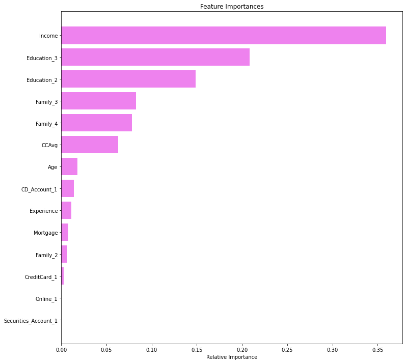

```python
# ranking the importance of variables

importances = model.feature_importances_
indices = np.argsort(importances)

plt.figure(figsize=(12,12))
plt.title('Feature Importances')
plt.barh(range(len(indices)), importances[indices], color='violet', align='center')
plt.yticks(range(len(indices)), [feature_names[i] for i in indices])
plt.xlabel('Relative Importance')
plt.show()
```

Income, and the level the education in a graduate or advanced/ professional are the top 3 factors

```python
# Choose the type of classifier

estimator = DecisionTreeClassifier(random_state=1)

# Grid of parameters to choose from

parameters = {'max_depth': np.arange(1,10),
              'min_samples_leaf': [1, 2, 5, 7, 10,15,20],
              'max_leaf_nodes' : [5, 10,15,20,25,30],
              'min_impurity_decrease': [0.0001,0.001,0.01,0.1]
             }

# Type of scoring used to compare parameter combinations
acc_scorer = metrics.make_scorer(metrics.recall_score)

# Run the grid search
grid_obj = GridSearchCV(estimator, parameters, scoring=acc_scorer,cv=5)
grid_obj = grid_obj.fit(xtrain, ytrain)

# Set the clf to the best combination of parameters
estimator = grid_obj.best_estimator_

# Fit the best algorithm to the data.
estimator.fit(xtrain, ytrain)
```

```
DecisionTreeClassifier(max_depth=5, max_leaf_nodes=15,
                       min_impurity_decrease=0.0001, random_state=1)
```

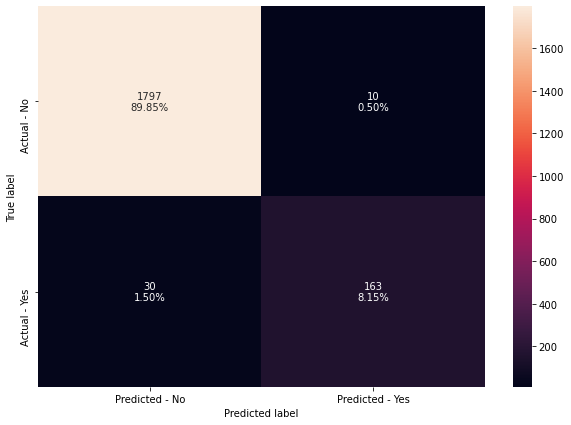

```python
make_confusion_matrix(estimator,ytest)
```

```python
get_recall_score(estimator)
```

```
Recall on training set :  0.9163763066202091
Recall on test set :  0.844559585492228
```

Recall on test set is not bad

```python
column_names = list(x.columns)
feature_names = column_names
print(feature_names)
```

```
['Age', 'Experience', 'Income', 'CCAvg', 'Mortgage', 'Family_2', 'Family_3', 'Family_4', 'Education_2', 'Education_3', 'Securities_Account_1', 'CD_Account_1', 'Online_1', 'CreditCard_1']
```

[figure not shown]

```python
plt.figure(figsize=(5,5))

tree.plot_tree(estimator,feature_names=feature_names,filled=True,fontsize=9,node_ids=True,class_names=True)
plt.show()
```

```python
clf = DecisionTreeClassifier(random_state=1)
path = clf.cost_complexity_pruning_path(xtrain, ytrain)
ccp_alphas, impurities = path.ccp_alphas, path.impurities
```

```python
pd.DataFrame(path)
```

|  | ccp_alphas | impurities |
| --- | --- | --- |
| 0 | 0.000000 | 0.000000 |
| 1 | 0.000316 | 0.000632 |
| 2 | 0.000317 | 0.001266 |
| 3 | 0.000323 | 0.002559 |
| 4 | 0.000376 | 0.003687 |
| 5 | 0.000443 | 0.004130 |
| 6 | 0.000444 | 0.005462 |
| 7 | 0.000444 | 0.005907 |
| 8 | 0.000444 | 0.006351 |
| 9 | 0.000500 | 0.006851 |
| 10 | 0.000500 | 0.008351 |
| 11 | 0.000617 | 0.009586 |
| 12 | 0.000651 | 0.010237 |
| 13 | 0.000797 | 0.011034 |
| 14 | 0.000878 | 0.014545 |
| 15 | 0.000889 | 0.015434 |
| 16 | 0.001071 | 0.016505 |
| 17 | 0.001192 | 0.017697 |
| 18 | 0.001280 | 0.018978 |
| 19 | 0.001683 | 0.020661 |
| 20 | 0.001971 | 0.024603 |
| 21 | 0.002429 | 0.027033 |
| 22 | 0.003780 | 0.030813 |
| 23 | 0.004751 | 0.035564 |
| 24 | 0.007284 | 0.042848 |
| 25 | 0.010207 | 0.053054 |
| 26 | 0.014137 | 0.067191 |
| 27 | 0.029173 | 0.125536 |
| 28 | 0.047493 | 0.173029 |

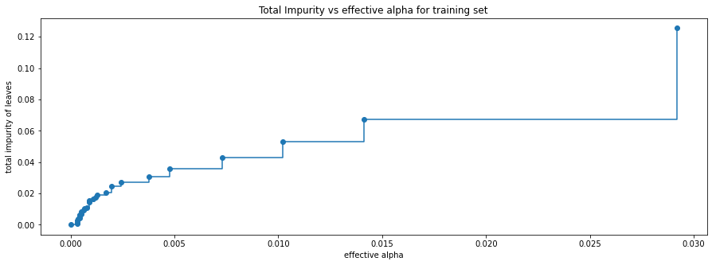

```python
fig, ax = plt.subplots(figsize=(15,5))
ax.plot(ccp_alphas[:-1], impurities[:-1], marker='o', drawstyle="steps-post")
ax.set_xlabel("effective alpha")
ax.set_ylabel("total impurity of leaves")
ax.set_title("Total Impurity vs effective alpha for training set")
plt.show()
```

```python
clfs = []
for ccp_alpha in ccp_alphas:
    clf = DecisionTreeClassifier(random_state=1, ccp_alpha=ccp_alpha)
    clf.fit(xtrain, ytrain)
    clfs.append(clf)
print("Number of nodes in the last tree is: {} with ccp_alpha: {}".format(
      clfs[-1].tree_.node_count, ccp_alphas[-1]))
```

```
Number of nodes in the last tree is: 1 with ccp_alpha: 0.04749278966498974
```

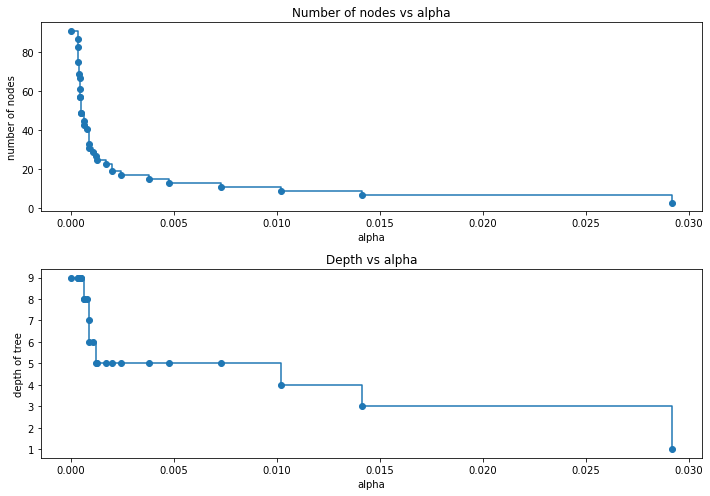

```python
clfs = clfs[:-1]
ccp_alphas = ccp_alphas[:-1]

node_counts = [clf.tree_.node_count for clf in clfs]
depth = [clf.tree_.max_depth for clf in clfs]
fig, ax = plt.subplots(2, 1,figsize=(10,7))
ax[0].plot(ccp_alphas, node_counts, marker='o', drawstyle="steps-post")
ax[0].set_xlabel("alpha")
ax[0].set_ylabel("number of nodes")
ax[0].set_title("Number of nodes vs alpha")
ax[1].plot(ccp_alphas, depth, marker='o', drawstyle="steps-post")
ax[1].set_xlabel("alpha")
ax[1].set_ylabel("depth of tree")
ax[1].set_title("Depth vs alpha")
fig.tight_layout()
```

```python
recall_train=[]
for clf in clfs:
    pred_train3=clf.predict(xtrain)
    values_train=metrics.recall_score(ytrain,pred_train3)
    recall_train.append(values_train)
```

```python
recall_test=[]
for clf in clfs:
    pred_test3=clf.predict(xtest)
    values_test=metrics.recall_score(ytest,pred_test3)
    recall_test.append(values_test)
```